# R Notebook

# Assignment Week 5

```r
suppressPackageStartupMessages({
  library(AnnotationHub)
  library(ensembldb)
  library(GenomicRanges)
  library(epiwraps)
  library(rtracklayer)
  library(ggplot2)
})
ah <- AnnotationHub(localHub=TRUE)
```

```
Using 'localHub=TRUE'
  If offline, please also see BiocManager vignette section on offline use
```

```
snapshotDate(): 2023-03-21
```

## Bivalent domains (H3K27me3 & H3K4me3) in mESC

Downloading of the correct files from the same cell type, because I’m not sure if I downloaded the correct files in the last assignment

```r
dir.create("mESC_bivalent")
download.file("https://www.encodeproject.org/files/ENCFF276FGU/@@download/ENCFF276FGU.bed.gz", "mESC_bivalent/H3K27me3.bed.gz")
H3K27me3 <- rtracklayer::import("mESC_bivalent/H3K27me3.bed.gz", format = "narrowPeak")
download.file("https://www.encodeproject.org/files/ENCFF187DLC/@@download/ENCFF187DLC.bed.gz", "mESC_bivalent/H3K4me3.bed.gz")
H3K4me3 <- rtracklayer::import("mESC_bivalent/H3K4me3.bed.gz", format = "narrowPeak")
```

Identifying bivalent domains in mESC:

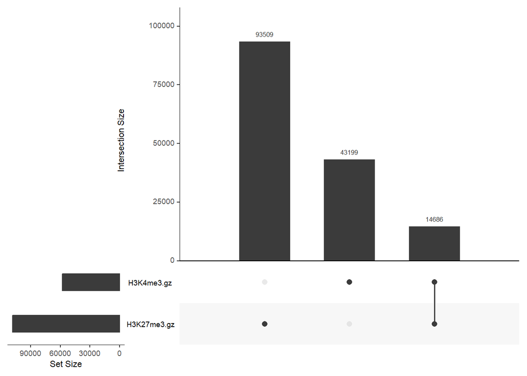

```r
peakfiles <- list.files("mESC_bivalent/", full.names = TRUE)
names(peakfiles) <- gsub("\\.bed", "", basename(peakfiles))
peaks <- lapply(peakfiles, FUN = rtracklayer::import, format = "narrowPeak")
regionUpset(peaks, nsets = length(peaks))
```

There are *14686* bivalent domains of HSK27me3 + H3K4me3 in mESC.

## What happens to those regions upon differentiation?

I’m choosing myoblasts as my differentiated cell type. Downloading the H3K27me3 & H3K4me3 peaks of myoblasts:

```r
download.file("https://www.encodeproject.org/files/ENCFF635VQE/@@download/ENCFF635VQE.bed.gz", "mESC_bivalent/H3K4me3Myoblast.bed.gz")
H3K4me3Myoblast <- rtracklayer::import("mESC_bivalent/H3K4me3Myoblast.bed.gz", "narrowPeak")
download.file("https://www.encodeproject.org/files/ENCFF071FEL/@@download/ENCFF071FEL.bed.gz", "mESC_bivalent/H3K27me3Myoblast.bed.gz")
H3K27me3Myoblast <- rtracklayer::import("mESC_bivalent/H3K27me3Myoblast.bed.gz","narrowPeak")
```

Identifying bivalent domains:

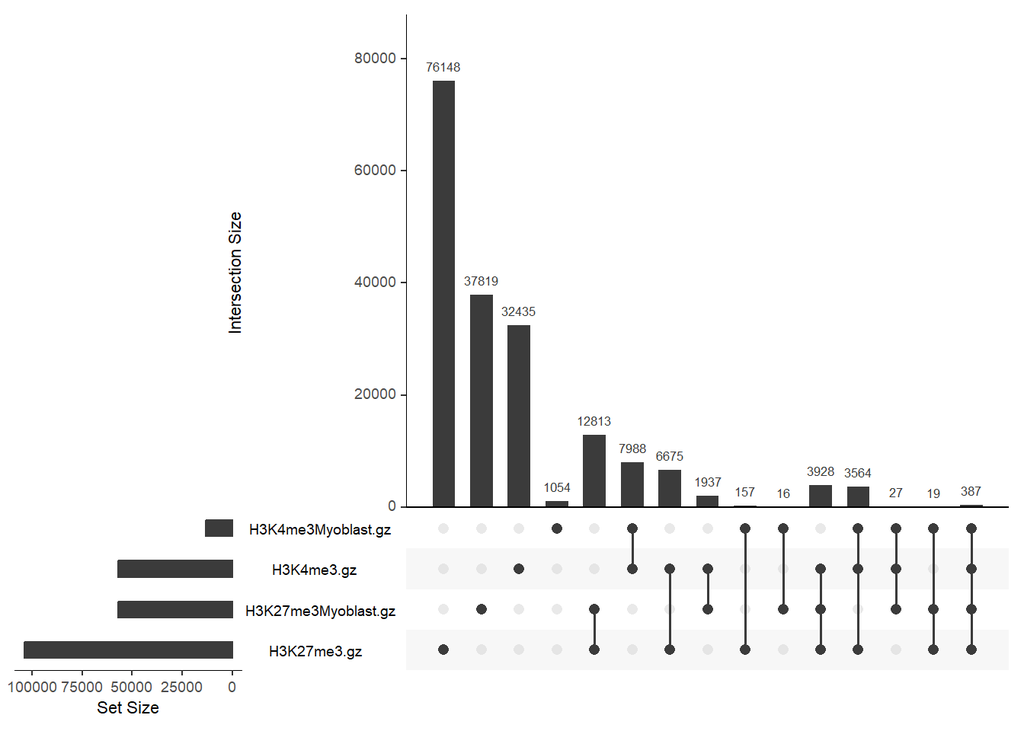

```r
peakfiles <- list.files("mESC_bivalent/", full.names = TRUE)
names(peakfiles) <- gsub("\\.bed", "", basename(peakfiles))
peaks <- lapply(peakfiles, FUN = rtracklayer::import, format = "narrowPeak")
regionUpset(peaks, nsets = length(peaks))
```

I find the question a little confusing, and therefore I’m not sure which overlaps are asked for.

*Bivalent Domains:* H3K27me3Myoblast + H3K4me3Myoblast = 16 H3K27me3Myoblast + H3K4me3Myoblast + H3K4me3 = 27 H3K27me3Myoblast + H3K4me3Myoblast + H3K27me3 = 19 H3K4me3Myoblast + H3K4me3 = 7988 H3K4me3Myoblast + H3K4me3 + H3K27me3 = 3564 H3K27me3Myoblast + H3K27me3 = 12813 H3K27me3Myoblast + H3K27me3 + H3K4me3 = 3928